# Assessing Ranking Fidelity of Competition Structures via Weighted Mutual Information

Zach Culp, Josie Peterburs, Dr. Gregory J. Matthews, Dr. Ryan P.A. McShane

[figure not shown]

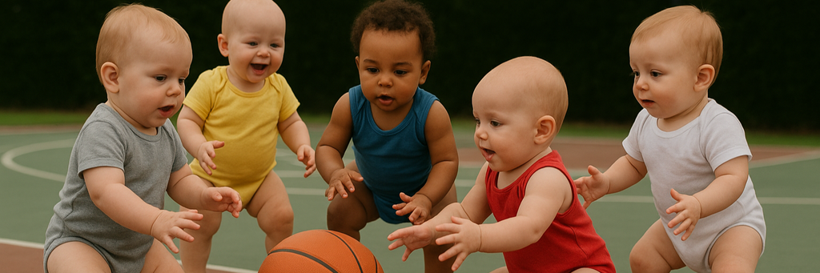

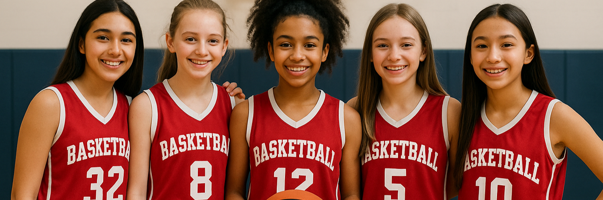

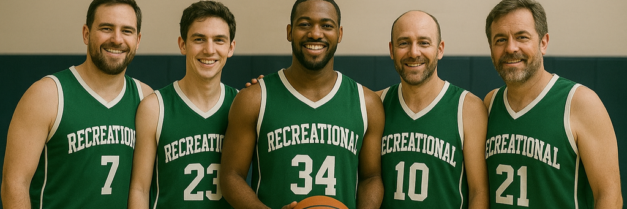

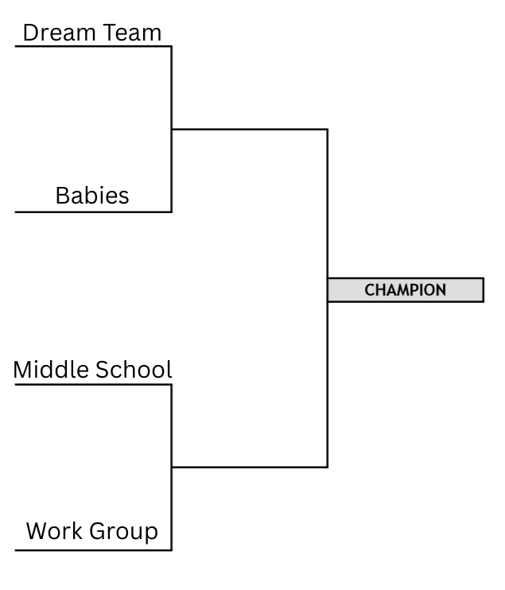

Good

Bad

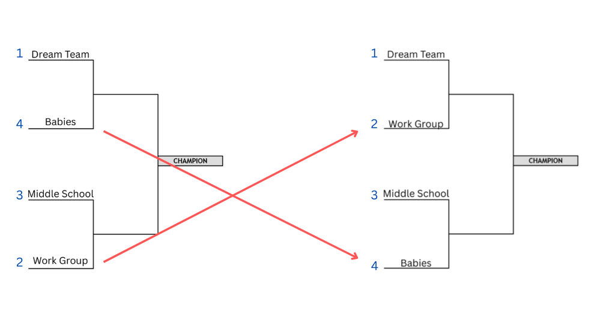

## Distribution of $\hat{r}$

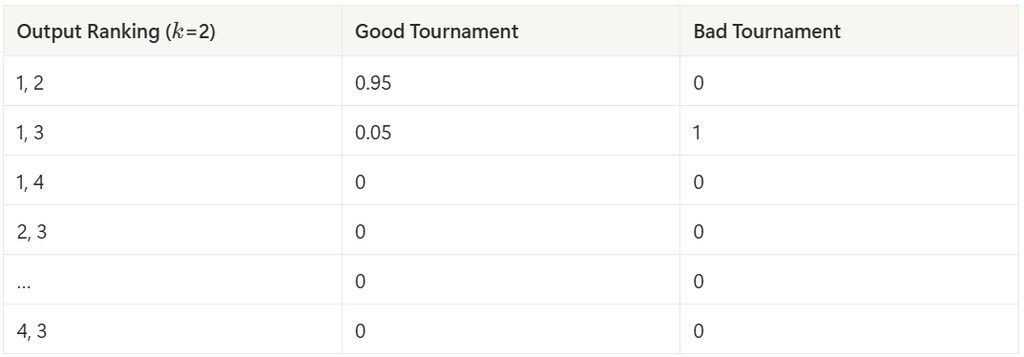

## Comparing Structures

- Which competition structure is best?
  - What is considered “best”?
  - A good tournament: top *k* teams produced by the tournament matches closely to the true top *k*

## Comparing Structures

- Which competition structure is best?
  - What is considered “best”?
  - A good tournament: top *k* teams produced by the tournament matches closely to the true top *k*
- **Effectivity**<sup>1</sup>: Interested in correctly ranking the best competitor as first
- **Efficacy**<sup>2</sup>: Final rankings should match the true rankings of all the competitors
[^1]: Glenn (1960)
[^2]: Lasek and Gagolewsk (2018), Sziklai, Biró, and Csató (2022)

## Effectivity and Efficacy

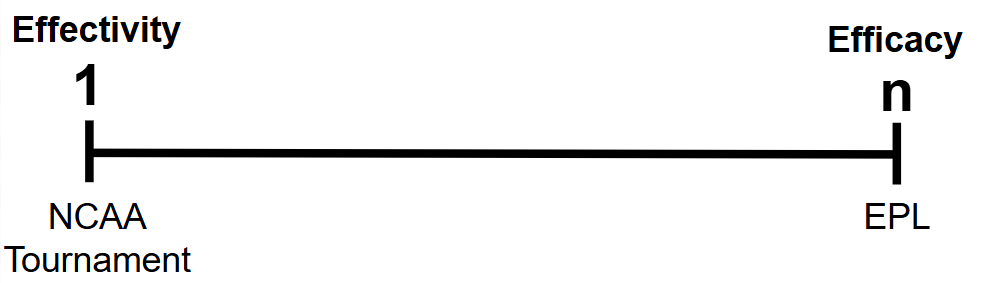

## Effectivity and Efficacy

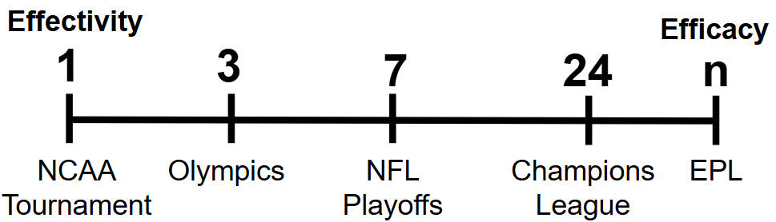

- **Salient ranks**: output ranks of the tournament you want to get correct
  - Effectivity: 1 is only salient rank (*k*=1)
  - Efficacy: 1 through $n$ are salient ranks (*k*=n)

## Goal

- Quantify how well a structure can accurately order the competitors using weighted mutual information
- We propose a metric that quantifies how effectively different tournament structures recover the true ranking of the teams

## Mutual Information

- The notation for mutual information is:
  $$I(X;Y) = \sum_{y \in Y}\sum_{x \in X} p(x,y) \log{\frac{p(x,y)}{p(x)p(y)}}$$
- In our case, it can be simplified to:

  $$I(r, \hat{r}) = n! \sum_{\hat{r}} p(r, \hat{r}) \log{\frac{p(r,\hat{r})}{(\frac{1}{n!})^2}}$$

## Weighted Mutual Information

- A limitation of mutual information is that it does not distinguish between the direction of information
- Given equal probabilities, the information found from a ranking of $(1,2,3,4)$ is equivalent to $(4,3,2,1)$
- Because of this, we proposed a new weighting function

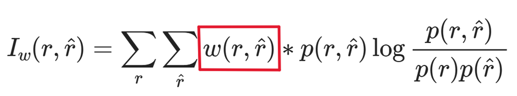

- The final metric we used normalizes the results: $\frac{I_w(r,\hat{r})}{H(r,\hat{r})}$

## Top K-teams Weighted Kendall

$$\tau_w = \frac{\sum_{i\neq j} W_{ij} \times \text{sgn}(i-j)\times \text{sgn}(R_i - R_j)}{\sum_{i,j} W_{ij} - \sum_i W_{ii}}$$

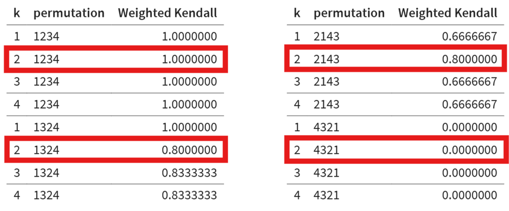

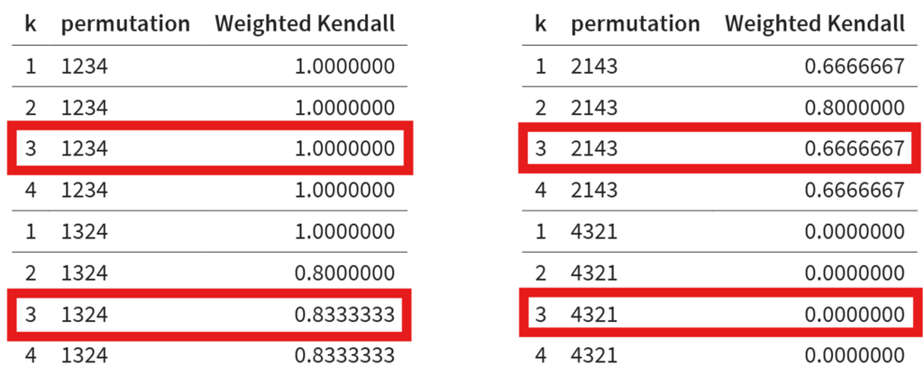

## Tournament Simulations

| r | theta | r_hat | Wins | Losses |
| --- | --- | --- | --- | --- |
| 1 | 1.221 | 3 | 2 | 1 |
| 2 | 0.765 | 4 | 1 | 2 |
| 3 | 0.431 | 2 | 2 | 1 |
| 4 | 0.140 | 1 | 3 | 0 |
| 5 | -0.140 | 7 | 0 | 1 |
| 6 | -0.431 | 6 | 0 | 1 |
| 7 | -0.765 | 5 | 0 | 1 |
| 8 | -1.221 | 8 | 0 | 1 |

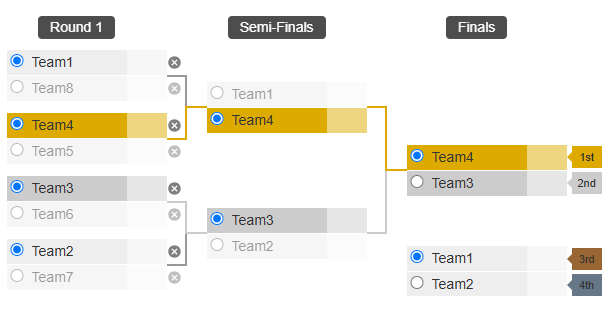

## Results

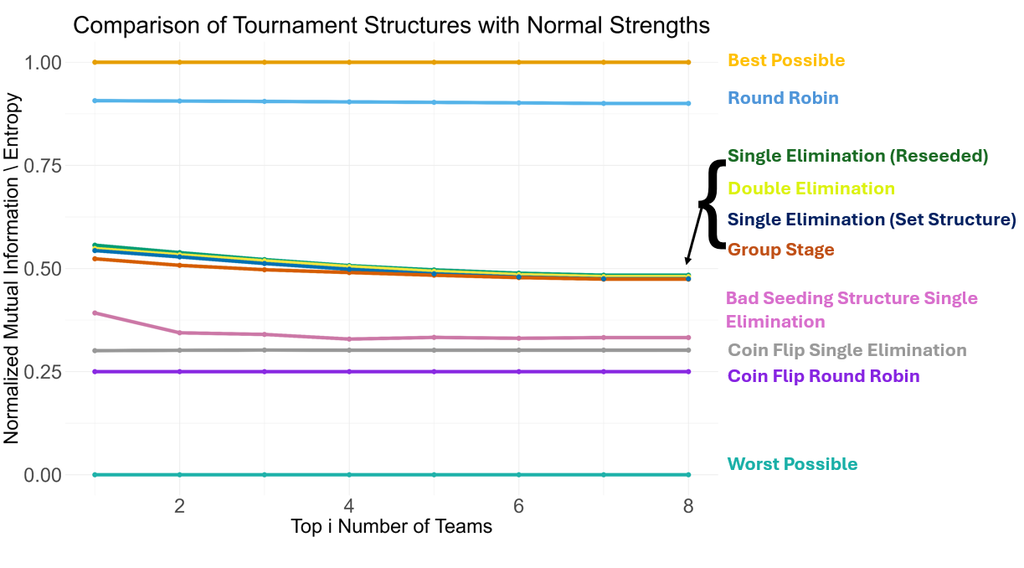

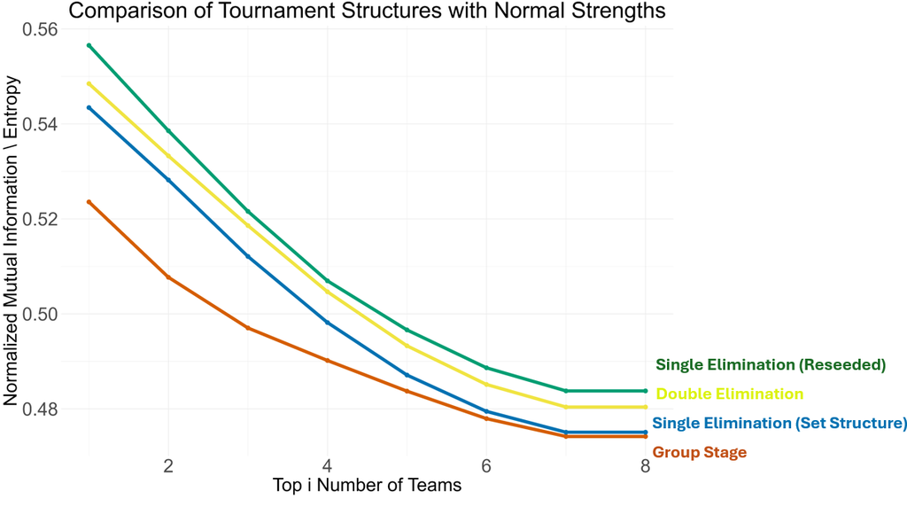

## Discussion

- We used mutual information to analyze competition structures in a range from efficacy to effectivity.
- Using the method, we found that Round Robin is the best structure, followed by Reseeded Single Elimination, Double Elimination, and Group Stage.
- Limitations: The “known” ranks are assigned using $\theta$ and, for some structure, the order of the ranks matter in the formatting of the structure
- Future Work: Examine how the distribution of $\theta$s influence the score of each competition structure

## References

- Appleton, David R. 1995. “May the Best Man Win?” Statistician 44 (4): 529.
- Csato, L. 2021. Tournament Design: How Operations Research Can Improve Sports Rules. 1st Ed. Cham, Switzerland: Palgrave Macmillan.
- Devriesere, Csató, K., and D. Goossens. 2025. “Tournament Design: A Review from an Operational Research Perspective.” European Journal of Operational Research 324 (1): 1–21.
- Glenn, W A. 1960. “A Comparison of the Effectiveness of Tournaments.” Biometrika 47 (3-4): 253–62.

## References

- Guiasu, Silviu. 1977. Information Theory with Applications. New York, NY: McGraw-Hill.
- Johnson, Sidney, and Rodney Fort. 2022. “Match Outcome Uncertainty and Sports Fan Demand: An Agnostic Review and the Standard Economic Theory of Ports Leagues.” Int. J. Emp. Econ. 01 (02).
- Lasek, Jan, and Marek Gagolewski. 2018. “The Efficacy of League Formats in Ranking Teams.” Stat. Modelling 18 (5-6): 411–35.
- Sziklai, Balázs R, Péter Biró, and László Csató. 2022. “The Efficacy of Tournament Designs.” Comput. Oper. Res. 144 (105821): 105821.